# Test a Perceptual Phenomenon

### Analyzing the Stroop Effect

Perform the analysis in the space below. Remember to follow [the instructions](https://docs.google.com/document/d/1-OkpZLjG_kX9J6LIQ5IltsqMzVWjh36QpnP2RYpVdPU/pub?embedded=True) and review the [project rubric](https://review.udacity.com/#!/rubrics/71/view) before submitting. Once you've completed the analysis and write up, download this file as a PDF or HTML file and submit in the next section.

(1) What is the independent variable? What is the dependent variable?

Dependent variable - Time taken by participants to name the ink colours.  
Independent variables - type of word i.e Congurent and Incongurent

(2) What is an appropriate set of hypotheses for this task? What kind of statistical test do you expect to perform? Justify your choices.

Null Hypothesis-> mean time taken to name Congruent words is equal to mean time taken to name Incongruent words.  
H(0): μ(c)=μ(I)  
Alternative Hypothesis-> mean time taken to name Congruent words is not equal to mean time taken to name Incongruent words.  
H(a): μ(c)!=μ(I)  
where:  
H(0)-> Null Hypothesis  
H(a)-> Alternative Hypothesis  
μ(c)-> Congruent population mean  
μ(I)-> Incongruent population mean  
Statistical Test-> t-test=>we are conducting a t-test because here the sample size is small,the experiment is performed by same person therefore we analyse by doing a paired t-test.  
Justification-> I am taking a 2-tailed hypothesis where Null hypothesis is μ(c)=μ(I) and Alternative Hypothesis is μ(c)!=μ(I),where μ(c) is mean time taken to name Congruent words and μ(I) is mean time taken to name Incongruent words. t-test is used as if the p-value is less than the alpha(α),we can reject the null otherwise we have to accept the null.I will be assuming 5% error rate that makes α=0.05

(3) Report some descriptive statistics regarding this dataset. Include at least one measure of central tendency and at least one measure of variability. The name of the data file is 'stroopdata.csv'.

```python
# Perform the analysis here
import numpy as np
import pandas as pd
import matplotlib.pyplot as plt
%matplotlib inline

df=pd.read_csv('stroopdata.csv')# reading the dataset
df.head()

mean_congruent=df.Congruent.mean() #calculate mean of Congurent
mean_incongruent=df.Incongruent.mean() #calculate mean of Incongurent

median_congruent=df.Congruent.median() #calculate median of Congurent
median_incongruent=df.Incongruent.median() #calculate median of Incongurent

sd_congruent=np.std(df['Congruent'],ddof=1) #calculate standard deviation of Congruent
sd_incongruent=np.std(df['Incongruent'],ddof=1) #calculate standard deviation of Incongruent

#printing the calculations done above
print('Mean of Congruent is =',mean_congruent)
print('Mean of Incongruent is =',mean_incongruent)
print('Median of Congruent is =',median_congruent)
print('Median of Incongruent is =',median_incongruent)
print('Standard Deviation of Congruent is =',sd_congruent)
print('Standard Deviation of Incongruent is =',sd_incongruent)
```

```
Mean of Congruent is = 14.051125
Mean of Incongruent is = 22.0159166667
Median of Congruent is = 14.3565
Median of Incongruent is = 21.0175
Standard Deviation of Congruent is = 3.55935795765
Standard Deviation of Incongruent is = 4.79705712247
```

## Here we calculated:

Mean of Congruent is = 14.051125  
Mean of Incongruent is = 22.0159166667  
Median of Congruent is = 14.3565  
Median of Incongruent is = 21.0175  
Standard Deviation of Congruent is = 3.55935795765  
Standard Deviation of Incongruent is = 4.79705712247  
These calculations give us a brief idea of the dataset,but we cannot tell much about dataset by calculating only these measures.

(4) Provide one or two visualizations that show the distribution of the sample data. Write one or two sentences noting what you observe about the plot or plots.

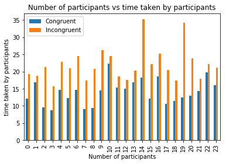

[figure not shown]

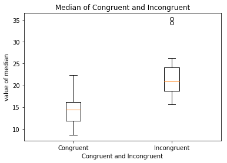

```python
# Build the visualizations here
df.plot( kind="bar"); #plot a bar graph of the dataframe df
plt.xlabel("Number of participants");# write the name for x-axis
plt.ylabel("time taken by participants");# write the name for y-axis
plt.title(" Number of participants vs time taken by participants "); # write the title for graph
plt.show() #to show the graph
df1=pd.read_csv('stroopdata.csv')

#df1['Mean_Congruent']=mean_congruent
#df1['Mean_Incongruent']=mean_incongruent
#df1=df1.drop(['Congruent','Incongruent'],axis=1)
#df1=df1.drop(df1.index[[1]])
#df1=df1.drop('Congruent',axis=1)
#df2['mean_Congruent']=mean_congruent
#df2['mean_Incongruent']=mean_incongruent
df1.plot.hist(orientation='horizontal') # plot a histogram with horizontal orientation
plt.xlabel("Freqency"); # write the name for x-axis
plt.ylabel("value of mean");# write the name for y-axis
plt.title(" Frequency vs value of mean "); # write the title for graph
plt.show()# to show the graph

plt.boxplot([df['Congruent'],df['Incongruent']]);#create a box plot for congruent and incongruent column
plt.xticks([1,2],['Congruent','Incongruent']);#give names to box plot
plt.xlabel("Congruent and Incongruent"); # write the name for x-axis
plt.ylabel("value of median");# write the name for y-axis
plt.title("Median of Congruent and Incongruent")# write the title for graph
plt.show()#to show the graph
#time taken by incongruentis more than congruent.
```

(5) Now, perform the statistical test and report the results. What is the confidence level and your critical statistic value? Do you reject the null hypothesis or fail to reject it? Come to a conclusion in terms of the experiment task. Did the results match up with your expectations?

```python
# Perform the statistical test here
from scipy import stats
stats.ttest_rel(df['Congruent'],df['Incongruent'])
```

```
Ttest_relResult(statistic=-8.020706944109957, pvalue=4.1030005857111781e-08)
```

By the Hypothesis fact if pvalue <= α then we reject the null. In this case we concluded that 4.1030005857111781e-08 <= 0.05 that is pvalue <= α therefore we reject the null and hence we can say that μ(c)!=μ(I) which means mean time taken to name Congruent words is not equal to mean time taken to name Incongruent words.Therefore we accept the Alternative Hypothesis.